# Objective

Our objective for this exercise is quite limited. We will use Bayesian optimization to estimate the optimal hyperparamters for XGBoost and Neural Network models. We will add noise to the graph of $y = \sin(2\pi x)$. Then we write the average sum of square error from cross validation as a function of our hyperparameters $\theta$. That is, we will consider $$ f: \theta \mapsto \text{average sume of square error given }\theta. $$ We will estimate $f$ using a Gaussian process $\hat{f}$. Minimize this estimate $\hat{f}$. Resample from $f$ at $$ \theta^* = \text{arg}\displaystyle\min_\theta \hat{f}(\theta). $$ Then repeate until we reach the maximum iterations or the process converges. This process is less accurate but less computationally intensive compared to something like grid search.

# Packages

```python
import numpy as np
import pandas as pd
import matplotlib.pyplot as plt
import xgboost as xgb
import sklearn.neural_network as nn
from sklearn.model_selection import cross_val_score
import GPyOpt
import time
```

# Generating the data

As mentioned previously, we will take the graph of $y = \sin(2\pi x)$ and then add noise. In particular, we will map $$ y_i \mapsto y_i + \epsilon_i $$ where $\epsilon_i\sim{\mathcal{N}(0, 0.1^2)}$ and $\epsilon_i$ is independent from $\epsilon_j$ for $i\neq j$. We will generate $N = 1 \times 10^5$ values because neural networks require a large amound of data to be effictive predicting models.

```python
# Record start time
start_time = time.time()

# Set the random seed so results are reproducable
np.random.seed(0)

# Number of data points; large so neural network is effective
N = 10**5

# Create data
x = np.linspace(0, 1, N)
y = np.sin(2 * np.pi * x)

# Add noise to y
y_noisy = y + np.random.normal(loc = 0, scale = 0.1, size = N)

# Reshape x
x = x.reshape((N, 1))
```

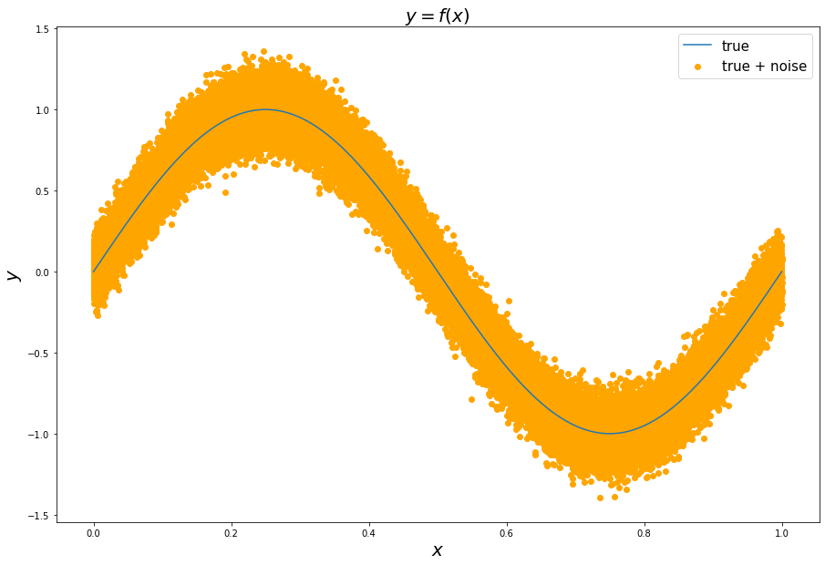

```python
fig, ax = plt.subplots(1, 1, figsize = (15, 10))

ax.set_title(r'$ y = f(x)$', fontsize = 20)
ax.set_xlabel(r'$x$', fontsize = 20)
ax.set_ylabel(r'$y$', fontsize = 20)

ax.plot(x, y, label = 'true')
ax.scatter(x_train, y_train, label = 'true + noise', color = 'orange')
ax.legend(fontsize = 15)

plt.show()
```